# Bruhn_C11_4

## C11.34 例題

前述の説明は、例題を提示することによって、よりよく理解または明確にすることができる。

第A20章のA20.5節、およびFig. A20.3とA20.4の例題にあるような構造配置の胴体があると仮定する。また、線形曲げ応力分布を適用するための慣性モーメントと中立軸を仮定する。これらの値はA20.8ページに与えられている。また、支持リングは外板に取り付けられており、15インチ間隔で配置されていると仮定する。リングは 1” × 3” × 1”、厚さ 0.040” の 24ST Zセクションである（Fig. C11.43 参照）。

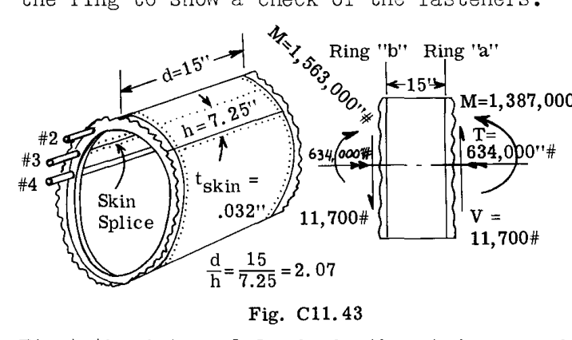

Fig. C11.43

ストリンガー#3、外板パネル2-3および3-4、そしてリングの解析を行う。また、ファスナのチェックを示すために、ストリンガー#3に沿って軸方向の外板スプライスがあり、リングに沿って垂直方向のスプライスがあると仮定する。

まず、ストリンガーと外板パネルの内部荷重を決定する。対角引張効果を得るために、この例ではベイの中央における「平均」荷重を使用する。

ベイの中央において、
$$M = 1,475,000 \text{ in. lb.}$$
$$T = 634,000 \text{ in. lb.}$$
$$V = 11,700 \text{ lb.}$$

最大ストリンガー応力はリングbで発生する：-

$$f_{\text{PMAX}} = \frac{MZ}{I} = \frac{1,563,000 (32.9)}{2382} = 21,600
\text{ psi.}$$

$$f_{\text{PAV.}} = \frac{1,475,000 (32.9)}{2382} = 20,400 \text{ psi.}$$

外板パネルのせん断流：-

$$q_{2-3} = \frac{VQ}{I} + \frac{T}{2A}$$

ここで、 $A$ は26個の三角形の面積からなる。

$$q_{2-3} = \frac{11,700 [.167(38.3) + .169(36.4)]}{2382} +
\frac{634,000}{2 \left[ 26 \times \frac{29.8}{2} \times 7.25 \right]}$$

$$= 61.6 + 113 = 175 \text{ lb./in.}$$

$$q_{3-4} = \frac{11,700 [.167(38.3) + .169(36.4) + .216(32.9)]}{2382} +
113$$

$$= 96 + 113 = 209 \text{ lb./in.}$$

パネル2-3および3-4について、平均の $q$ 、曲げ応力などを仮定して、対角引張効果を計算する。

$$q_{\text{AV}_{2-4}} = \frac{175 + 209}{2} = 192 \text{ lb./in.}$$

$$f_{\text{sAV}_{2-4}} = \frac{192}{t} = \frac{192}{.032} = 6000 \text{
psi.}$$

平均クリティカルせん断座屈応力は、式(75)を使用して計算される。

まず、外板の座屈が発生しない場合、2つのパネルの平均圧縮応力は、ほぼそれらの間のストリンガーの応力となり、したがって

$$f_{\text{Cpanels}} = f_{\text{PAV.}} = 20,400 \text{ psi.}$$

となり、定数 $B$ は次のようになる。

$$B = \frac{f_{\text{C}}}{f_{\text{s}}} = \frac{20,400}{6,000} = 3.40$$

第C9章からのクリティカル純せん断座屈応力方程式は、

$$F_{\text{scr}} = \frac{\pi^2 k_{\text{s}} E}{12(1 -
u_{\text{e}}^2)} \left( \frac{t}{b} \right)^2$$

第C9章より、 $k_{\text{s}} = 16.8$ 。

$$F_{\text{scr}} = \frac{\pi^2 \times 16.8 \times 10,600,000}{12(1 -
.3^2)} \left( \frac{.032}{7.25} \right)^2 = 3140 \text{ psi.}$$

純圧縮の場合、第C9章からのクリティカル座屈応力方程式は、

$$F_{\text{Ccr}} = \frac{\pi^2 k_{\text{c}} E}{12(1 -
u_{\text{e}}^2)} \left( \frac{t}{b} \right)^2$$

$k_{\text{c}} = 15.9$ （第C9章より）。

$$F_{\text{Ccr}} = \frac{\pi^2 \times 15.9 \times 10,600,000}{12(1 -
.3^2)} \left( \frac{.032}{7.25} \right)^2 = 2980 \text{ psi.}$$

したがって、 $A = F_{\text{Ccr}}/F_{\text{scr}} = 2980/3140 = .950$ 。

座屈応力は材料 constituents の比例限度応力を下回っているため、薄肉構造で通常必要とされるような塑性修正は必要なかった。したがって、応力比（ $A$ ）は $k_{\text{c}}/k_{\text{s}}$ として直接得ることができる。

次に：-

$$R_{\text{c}} = \frac{-\frac{B}{A} + \sqrt{\left(\frac{B}{A}\right)^2 +
4}}{2}$$

$$= \frac{-\frac{3.40}{.950} + \sqrt{\left(\frac{3.40}{.950}\right)^2 +
4}}{2} = .26$$

そして、式(75)から

$$f_{\text{sCr}_{2-4}} = F_{\text{scr}} \times R_{\text{c}} = 3140 (.26) =
815 \text{ psi}$$

これは圧縮が存在するため、非常に小さい。

次に、

$$\frac{f_{\text{sAV}}}{f_{\text{sCr}_{2-4}}} = \frac{6000}{815} = 7.36$$

これで $k$ を決定できる：

$$300 \frac{td}{Rh} = \frac{300 (.032)}{30} (2.0)^* = .64$$

Fig. C11.19 より、 $k = .75$ 。

ストリンガーとリングの応力の式は、 $\alpha$ の関数として書くことができる。式(85)に代入し、右辺の最初の項に $f_{\text{PAV}}$ を使用すると、

$$f_{\text{STR}} = 20,400 + \frac{.75(6000) \cot
\alpha}{\frac{.180}{(7.25)(.032)} + .5(1 - .75)(.26)}$$

$$= 20,400 + 5570 \cot \alpha$$

これがストリンガーの「平均」応力である。

リングの式(89)に代入し、 $A_{\text{RG}} = (1" + 3" + 1")(.040") = .20 \text{ in.}^2$ を使用すると、

$$f_{\text{RG}} = \frac{.75 (6000) \tan \alpha}{\frac{.20}{(15)(.032)} +
.5 (1 - .75)}$$

$$= 8,300 \tan \alpha$$

式(94)、(86)、(90)および上記の応力式、また式(94)用の Fig. C11.36 を使用して、逐次近似によって $\alpha$ を決定する。非常に多くの圧縮が含まれているため、まず $\alpha = 45^{\circ}$ と仮定する。Fig. C11.36 より

$$\frac{\epsilon E}{f_{\text{s}}} = 1.83 \quad \epsilon = \frac{1.83
(6000)}{10.6 \times 10^6} = 1036 \times 10^{-6}$$

$$\epsilon_{\text{STR}} = \frac{20,400 + 5570 (1.0)}{10.6 \times 10^6} =
2450 \times 10^{-6}$$

$$\epsilon_{\text{RG}} = \frac{8,300 (1.0)}{10.6 \times 10^6} = 782 \times
10^{-6}$$

ここで、式(95)を使用して「新しい」 $\alpha$ を解く

$$\tan^2 \alpha = \frac{(1036 + 2450)10^{-6}}{(1036 + 782)10^{-6} +
\frac{1}{24} \left( \frac{7.25}{30} \right)^2} = 0.822$$

$$\tan \alpha = .907$$

$$\alpha = 42.2^{\circ} \quad \text{（これは想定した } 45^{\circ} \text{
より小さい）}$$

2回目の試行として、 $\alpha = 42.4^{\circ}$ と仮定する。

$$\frac{\epsilon E}{f_{\text{s}}} = 1.84 \quad \text{（Fig. C11.36 より）}$$

$$\epsilon = 1.84 \times 6000 / 10.6 \times 10^6 = 1041 \times 10^{-6}$$

$$\epsilon_{\text{STR}} = [20400 + 5570(\cot \alpha)] / 10.6 \times 10^6 =
2505 \times 10^{-6}$$

$$\tan^2 \alpha = \frac{(1041 + 2505)10^{-6}}{(1041 + 752)10^{-6} +
.00243} = .84$$

これより、想定した $42.4^{\circ}$ に対して $\alpha = 42.6^{\circ}$ となる。理論の精度からして、これ以上の詳細なチェックは必要ないため、 $\alpha$ は $42.4^{\circ}$ とする。

対応するストリンガーおよびリングの応力は以下の通りである：

$$f_{\text{STR}} = 20,400 + 5570 (1.092)$$

$$= 20,400 + 6090$$

これらは局所強度チェックには加算されない。これらは柱の安定性チェックのために加算される。右辺の項は平均応力であり、対角引張効果による強制クリップリングである。

$$f_{\text{RG}} = 8,300 (.917) = 7,610 \text{ psi.}$$

また、式(87)から、

$$M_{\text{STR}} = \frac{6000(7.25)(.032)(15)^2(.75)(.917)}{24(30)} = 299
\text{ lb./in.}$$

および

$$f_{\text{b}} = \frac{M_{\text{STR}} c}{I_{\text{STR}}} = \frac{299
(.562)}{.0418} = 4020 \text{ psi.}$$

軸方向スプライスに沿ったリベット荷重/インチは、式(96)から、

$$\text{Load/in.} = 6000(.032) \left[ 1 + .75 \left( \frac{1}{.74} \right)
- 1 \right] = 243 \text{ lb./in.}$$

そして、周方向スプライスに沿っては、式(97)から、

$$\text{Load/in.} = 6000(.032) \left[ 1 + .75 \left( \frac{1}{.675}
\right) - 1 \right] = 262 \text{ lb./in.}$$

上記の応力、 $f_{\text{MAX}}/f$ 比、および許容値から、十分な強度があるかどうかのチェックを次のように行うことができる：-

### ストリンガー：-

リング(b)との接合部において、

$$f_{\text{STR}} = (21,600 + f_{\text{b}}) + 6090 \text{ psi.}$$

適切な局所強度のために、

$$\frac{f_{\text{c}} + f_{\text{b}}}{F_{\text{cc}}} +
\frac{f_{\text{ST}}}{F_{\text{ST}}} \le 1.0$$

$$F_{\text{ST}} = 26,000 k^{2/3} \left( \frac{t_{\text{ST}}}{t}
\right)^{1/3}$$

（Fig. C11.38 からも決定可能）。

したがって、*

$$\frac{21,600 + 4020}{27,000} + \frac{6090}{26,500} = 1.19 \quad
\text{（ストリンガーは不十分）}$$

ストリンガーの中央において、

$$f_{\text{STMAX}} = f_{\text{ST}} \left(
\frac{f_{\text{STMAX}}}{f_{\text{ST}}} \right)$$

Fig. C11.21 から

$$\frac{f_{\text{STMAX}}}{f_{\text{ST}}} \approx 1.02$$

したがって、

$$f_{\text{STMAX}} = 6090 (1.02) = 6210 \text{ psi.}$$

相互作用公式を使用すると、次のようになる：

$$\frac{20,400 + 4020}{27,000} + \frac{6210}{26,500} = 1.14 \quad
\text{（ストリンガーは不十分）}$$

両端固定柱としてチェックすると、

$$\rho = \sqrt{\frac{I}{A}} = \sqrt{\frac{.0418}{.18}} = .482$$

$$L/2\rho = \frac{15}{2(.482)} = 15.6$$

$$F_{\text{COL.}} \approx 26,500 \quad \text{（Fig. C7.33 参照）}$$

したがって、

$$\frac{20,400 + 6090}{26,500} = 1.00 \quad
\text{（ビームコラム作用を考慮して、1.00より少し小さい0.85程度であるべきである）}$$

### リング

外板に取り付けられたリングは、強制クリップリング応力 $f_{\text{RG}}$ のみを受ける。

ストリンガー接合部の中間において、この作用は最大となり、適切な局所強度のために、

$$\frac{f_{\text{RGMAX}}}{F_{\text{RG}}} \le 1.0$$

Fig. C11.21 のデータを使用して、

$$f_{\text{RGMAX}} = f_{\text{RG}} \times
\frac{f_{\text{RGMAX}}}{f_{\text{RG}}}$$

$$= 7,610 \times 1.0 = 7,610 \text{ psi.}$$

したがって、

$$\frac{f_{\text{RGMAX}}}{F_{\text{RG}}} = \frac{7,610}{23,100} = .33
\quad \text{（十分）}$$

同じ圧縮応力（および荷重 $P = f_{\text{RG}} \times A_{\text{RG}}$ ）がストリンガー接合部に存在する。通常行われるように、ストリンガーを通過させるためにリングにノッチがある場合、リングのネットセクションは、ノッチのないリング断面積の図心に位置するこの荷重を支持できなければならない。通常、これはノッチ部周辺の局所的な「補強」を意味し、ストリンガーをリングに取り付けるクリップに組み込まれることもある。

実際には、リングはストリンガーと同様に、その前後のパネルにおける平均せん断応力を受ける。この例では、これらは等しいと仮定されている。

### 外板

Fig. C11.42 から得られる許容せん断応力は、

$$F_{\text{s}} = 21,800$$

文献 (3) の方法を使用すると、

$$F_{\text{sALL}}^* = 20,800 \quad \text{（Fig. C11.41a および b より）}$$

$$\Delta = .38 \quad \text{（Fig. C11.40 より）}$$

したがって、

$$F_{\text{s}} = 20,800 (.65 + .38) = 21,400 \text{ psi.}$$

いずれの場合も、実際のせん断応力 $f_{\text{s}} = 6000 \text{ psi}$ に対する安全マージンが大きいことが示されている（示されているのは平均値）。

（中立軸に近いパネルは、当然、より大きなせん断応力を受けることになる。）

### ファスナ

この領域で使用されるすべてのファスナは、当然、前述の計算通りにスプライス部における荷重/インチを伝達できなければならない。しかし、この基準は間隔を決定するものではないかもしれない。それらはまた、式(98)の、.032の外板に取り付けられた場合の許容引張荷重を持たなければならない。

$$\text{Tens. All. Load/Inch} = .22 (.032)(62,000) = 435 \text{ lb.}$$

Fig. C11.37 から、ディンプル加工された .032 外板に 1/8” 皿頭アルミリベットを 0.50” 間隔で配置すれば十分であるか、または「フラッシュ」ジョイントが要求されない場合は 0.65” 間隔で 1/8” 丸頭リベットを配置すれば十分であることがわかる。このケースでは引張の要件が最も厳しい。

### 一般不安定性

リングとストリンガーの「ネットワーク」の全体的な不安定性に対するチェックは、Fig. C11.39 を使用して行うことができる。これは、平板ウェブビームの直立材に対する柱の安定性チェックに類似している。しかし、湾曲ウェブの場合、不安定性の防止において張力外板による「助け」は得られない。

この例題において、不安定性による「崩壊」が発生する外板のせん断応力を計算するために使用される値は以下の通りである：

$$\rho_{\text{ST}} = .414 \quad \text{（第A20章の Fig. A20.4
におけるストリンガー } S_{\text{s}}\text{）}$$

$$\rho_{\text{RG}} = .819$$

（これらの回転半径は、文献 (3) に従い、ストリンガーについては $w_{\text{e}} = h$ 、リングについては $w_{\text{e}} = d$ として、外板の全幅が作用しているものとして得られる。）

したがって、

$$\frac{(\rho_{\text{ST}} \rho_{\text{RG}})^{7/8} \times 10^4}{(dh)^{3/8}
R^{3/4}} = \frac{(.414 \times .819)^{7/8} \times 10^4}{(15 \times
7.25)^{3/8} (30)^{3/4}}$$

$$= \frac{.386 \times 10^4}{133} = 29$$

Fig. C11.39 より

$$\frac{F_{\text{sINST}}}{E_{\text{c}}} > 3.0 \quad \text{したがって }
F_{\text{sINST}} > 3 \times 10.3 \times 10^6 > 30,900 \text{ psi}$$

であり、崩壊に対する安全マージンは、

$$M.S. = \frac{F_{\text{sINST}}}{f_{\text{s}}} - 1 = \frac{30,900}{6,000}
- 1 = \text{large（大）}$$

もちろん、他のパネルはより大きなせん断応力と、より小さな許容応力 $F_{\text{sINST}}$ を持つ可能性があり、したがってよりクリティカルになる可能性があるが、見ての通り、十分な剛性があるため、不安定性の問題は予想されない。

## LONGERON TYPE SYSTEM（ロンジロン型システム）

### C11.35

ロンジロン型の構造システムは、全般的な解析の観点からいくぶん単純である。これは、当然のことながら、主に軸方向荷重を支持する部材が少なく、せん断荷重が変化するせん断パネルが多くないためである。このタイプの構造は、特定の航空機の重量および製造コストの観点から最適な配置である場合とそうでない場合がある。しかし、これは最適化研究に依存するため、ここでの議論の対象ではない。しかし、ここに提示された解析手法は、そのような研究の背後にある計算において役割を果たすであろう。

胴体のロンジロン構造システムの代表的な断面形状のいくつかを Fig. C11.44 に示す。

[figure not shown]

Fig. C11.44

Fig. (a) は、複数の平面で曲げモーメントが作用する場合の平衡に少なくとも3つの軸荷重支持部材が必要であるため、ロンジロンの数に関して最小の配置を示している。しかし、この配置は「フェイルセーフ」設計ではないという欠点がある。これは、いずれか1つの部材が破損した場合、設計極限荷重の任意の割合（通常は50%から67%）を依然として支持できる構造が残らないことを意味する。

Fig. C11.44b に示すシステムはこれを可能にするため、「フェイルセーフ」の観点から許容される最小のタイプ（4ロンジロン）である。設計および製造の他の要因によっては、Fig. (c) のようにより多くのロンジロンが使用されることもある。

しかし、ロンジロンシステムは、強度重量効率の観点から、ストリンガーシステムよりも密な間隔のリングを必要とする。前述のように、支持リングまたはフレームの最適な間隔は、異なる板厚、サイズ、リングの間隔、および外板の厚さを伴う多くの試行計算を行った後に決定される。

ストリンガー構造の前の議論と同様に、リングは外板を支持し、それを長さ方向に小さなパネルに分割する。それらはまた、平面ウェブビームの直立材（補強材）と同様に、ロンジロンの両側の外板による不均等な張力場の「引っ張り」による曲げに対してロンジロンを支持する。ロンジロン構造システムには「フローティング」リングは存在しない。

座屈後、このシステムの外板には引張対角線が存在し、これは密に配置されたストリンガー間で「平坦」である代わりに、回転一葉双曲面上に位置する。すなわち、それらは密に配置されたリング間で対角線方向に平坦になる。この作用は文献 (8) で議論されており、読者はワグナーによって最初に提示された基本理論を参照されたい。このシステムでは、リング間隔「d」は $d < h$ となる（Fig. C11.34 参照）。

### C11.36

ロンジロンシステムの応力と許容値の計算手順は、ストリンガーシステムに使用された手順といくぶん類似している。読者はその違いに注目されるであろう。

1. まず、チェックするベイにおいて、適用された荷重によるロンジロンとせん断パネルの一次内部荷重分布を決定する。これは、ほとんどの場合、曲げの工学理論を使用して、C11.34節と同様に行うことができる。判断と経験、および構造の性質がそれを示している他の場合には、適用された荷重による一次荷重分布の決定に第A8章の方法を使用することができる。
2. 次に、外板パネルのクリティカルせん断座屈応力を決定する。実際の状況では圧縮応力もほぼ常に存在するため、純せん断座屈は発生しない。したがって、ストリンガー設計の場合に議論したように、何らかの合理的な相互作用を使用して「減少した」せん断座屈応力を得る必要がある。これは、例えば、安全側に見積もるために高い方に重みを付けた、パネル内の何らかの「平均」圧縮応力を使用することによって行うことができる。これにより、C11.32節の相互作用法を使用することができ、ここで

$$R_{\text{c}} = \frac{-\frac{B}{A} + \sqrt{\left(\frac{B}{A}\right)^2 +
4}}{2} \quad \text{（式(74)と同様）}$$

であり、(A) はリング間の長さ “d”、ロンジロン間の高さ (h)（Fig. C11.34 のように円周に沿って測定）の湾曲パネルに対して決定される。(B) は、調査対象の特定の荷重条件に対する圧縮応力とせん断応力の比（ $f_{\text{c}}/f_{\text{s}}$ ）である。圧縮応力は、計算対象のパネルがまだ座屈していないものとして計算する必要がある。そして、式(75)のように

$$f_{\text{sCr}} = R_{\text{c}} F_{\text{sCr}}$$

は、減少したせん断座屈応力 $f_{\text{sCr}}$ を与える。

せん断に加えて圧縮ではなく引張ひずみが存在する場合、式(77)のように

$$R_{\text{T}} = 1.0 + \frac{f_{\text{t}}}{2F_{\text{Ccr}}}$$

となり、そのとき

$$f_{\text{sCr}} = R_{\text{T}} F_{\text{sCr}} \quad
\text{（式(79)と同様）}$$

となる。

3. 次に、上記(2)で決定された $f_{\text{sCr}}$ を使用して、荷重比 $f_{\text{s}}/f_{\text{sCr}}$ を計算することができる。
4. これに続いて、Fig. C11.19 から対角引張係数 $k$ を得ることができる。
5. ロンジロンの全軸応力は、次のように書くことができる：

$$f_{\text{L}} = f_{\text{p}} + f_{\text{D.T.}}$$

$$= f_{\text{p}} - \frac{\frac{k_1 f_{\text{s}_1} \cot
\alpha_1}{2A_{\text{L}}} + .25 (1 - k_1)R_{\text{c}}}{h_1 t_1} -
\frac{\frac{k_2 f_{\text{s}_2} \cot \alpha_2}{2A_{\text{L}}} + .25 (1 -
k_2)R_{\text{c}}}{h_2 t_2} \quad \cdots \quad (104)$$

ここで

$f_{\text{p}}$ = ステップ(1)からの一次ロンジロン応力、引張の場合は (+)、圧縮の場合は (-)

$A_{\text{L}}$ = ロンジロン断面積

および

$k$ , $f_{\text{s}}$ , $\cot \alpha$ , $R_{\text{c}}$ （または $R_{\text{T}}$ ）、 $h$ 、および $t$ は前述の定義の通りである。一方の添字 (1) はロンジロンの上のパネル用であり、他方の (2) はロンジロンの下のパネル用である。

6. 対角引張効果による支持リング（またはフレーム）の平均応力は、次の公式によって与えられる（これはストリンガーの場合とは異なることに注意）：

$$f_{\text{RG}} = \frac{\frac{k f_{\text{s}} \tan
\alpha}{A_{\text{RGe}}}}{dt} + .5 (1 - k) \quad \cdots \quad (105)$$

ここで、式(58)と同様に、

$$A_{\text{RGe}} = \frac{A_{\text{RG}}}{1 + \left( \frac{e}{\rho}
\right)^2}$$

この公式は、平面ウェブビームシステムにおける単一の直立材の「有効」面積に対する公式（C11.20節）に類似しており、ここで

$e$ = リングの重心から外板までの距離

$\rho$ = 外板に平行な軸に関するリング（断面）の回転半径。

式(105)は、リングの両側のパネルにおいて $k$ , $f_{\text{s}}$ , $d$ , $t$ などが同じであることを前提としている。そうでない場合は、何らかの平均値を使用するか、または上記(5)のロンジロンで行われたように、 $f_{\text{RG}}$ を2つの対角引張効果（各サイドパネルについて）の和として書く必要がある。

リングにおける「最大」応力 $f_{\text{RGMAX}}$ は、前と同様に、式(59)となる：

$$f_{\text{RGMAX}} = f_{\text{RG}} \left(
\frac{f_{\text{RGMAX}}}{f_{\text{RG}}} \right)$$

ここで

$$\frac{f_{\text{RGMAX}}}{f_{\text{RG}}} \quad \text{は Fig. C11.21
から得られる。}$$

7. 次の問題は、対角引張角度 $\alpha$ の決定である。 $\alpha$ を評価する方法はいくつかある。次の4つである：-
- 1. かなりの量の圧縮ひずみが存在する場合は、単純に $\alpha = 45^{\circ}$ と仮定する。
- 2. 軸方向ひずみが存在しないか、またはほとんど存在しない場合（せん断のみ）は、Fig. C11.45 を使用して $\alpha$ を得る。
- 3. 式(78)から、座屈を防止するのに十分な引張応力（またはひずみ）が存在する場合、当然 $\alpha = 0^{\circ}$ である。
- 4. 次のように逐次近似法によって $\alpha$ を計算する。これは最も面倒な方法であり、特に予備設計においては、ほとんどの場合上記 (a) および (b) で十分である。

角度 $\alpha$ は、文献 (3) の次の方程式を満たさなければならず、これはストリンガーの場合とは異なる：

$$\tan^2 \alpha = \frac{\epsilon - \epsilon_{\text{L}}}{\epsilon -
\epsilon_{\text{RG}} + \frac{1}{8} \left( \frac{d}{R} \right)^2 \tan^2
\alpha} \quad \cdots \quad (106)$$

ここで、前と同様に、式(94)から、

$$\epsilon = \frac{f_{\text{s}}}{E} \left[ \frac{2k}{\sin 2\alpha} + \sin
2\alpha (1 - k)(1 +
u) \right]$$

または括弧内の式に Fig. C11.36 を使用する。

$$\epsilon_{\text{L}} = \frac{f_{\text{L}}}{E} \quad \text{（式(104)からの
} f_{\text{L}}\text{）}$$

$$\epsilon_{\text{RG}} = \frac{f_{\text{RG}}}{E} \quad
\text{（式(105)からの } f_{\text{RG}}\text{）}$$

式(106)は、ストリンガーシステムの説明で行われたように、逐次近似によって解かれなければならない。

8. その後、応力比を使用して、次のように強度チェックを行うことができる。
- 1. **ロンジロン：**

  $$\frac{f_{\text{p}}}{F_{\text{cc}}} +
  \frac{f_{\text{D.T.}}}{F_{\text{L}}} \le 1.0$$

  ここで $F_{\text{cc}}$ は「自然な」クリップリング強度であり、 $F_{\text{L}}$ は Fig. C11.38 から得られる。

  厚いロンジロンの場合、強度チェックとして以下がよく使用される：

  $$\frac{f_{\text{p}} + f_{\text{D.T.}}}{F_{\text{cc}}} \le 1.0$$

  すなわち、一次効果と対角引張効果が単純に加算され、 $F_{\text{cc}}$ に対してチェックされる。
- 2. **リング：**

  $$\frac{f_{\text{RG}}}{F_{\text{RG}}} \le 1.0$$

  対角引張以外の荷重（すなわちバルクヘッド型の荷重、第A21章参照）による応力がリングに存在する場合、相互作用方程式が使用される。

  $$\frac{f_{\text{p}}}{F_{\text{cc}}} + \frac{f_{\text{RG}}}{F_{\text{RG}}}
  \le 1.0$$

  ここで $f_{\text{p}}$ は対角引張効果以外の荷重による応力である。
- 3. **外板：**

  強度チェック：

  $$\frac{f_{\text{s}}}{F_{\text{s}}} \le 1.0$$

  ここで $F_{\text{s}}$ は Fig. C11.42 から得られる。

  永久座屈：

  制限荷重において永久座屈は通常許容されない。

  $$\frac{f_{\text{sLIMIT}}}{F_{\text{s p.b.}}} \le 1.0$$

  ここで $F_{\text{s p.b.}}$ は Fig. C11.46 から得られる。
- 4. **一般不安定性：**

  $$\frac{f_{\text{s}}}{F_{\text{sINST}}} \le 1.0$$

  ここで $F_{\text{sINST}}$ は Fig. C11.39 から得られる。ここでは0.15から0.20の安全マージンを維持することが推奨される。Fig. C11.39 では有効外板は使用されておらず、 $\rho_{\text{LONG}}$ は最大で .34 であることに注意されたい。
- 5. スプライス部におけるリベットの荷重などは、ストリンガーシステム（式(96)および(97)）と同じである。

上記 (1) から (8) に概説した手順は、例題を使用することで最もよく説明できる。

### Fig. C11.37 例題

Fig. C11.47 に示すような断面を持つロンジロンタイプの胴体構造を考える。ロンジロンとリングの詳細と断面特性を図に示す。

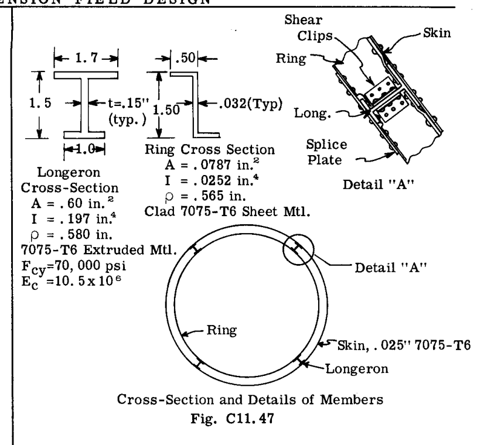

Fig. C11.47

構造断面の特性を Fig. C11.48 に示す。示されている特性は、曲げモーメントによって上部外板が圧縮され、下部外板が引張される場合のものである。したがって、示されているように、上部外板は早期に座屈する。

この例題では、適用される荷重が次のようであると仮定する：

$$M = 2,135,000 \text{ in.lb.（上部外板が圧縮）}$$

$$T = 600,000 \text{ in. lb.（逆転可能）}$$

$$V = 18,000 \text{ lb.（上部外板に圧縮を発生させる）}$$

これらはチェック対象のベイの中央における荷重である。

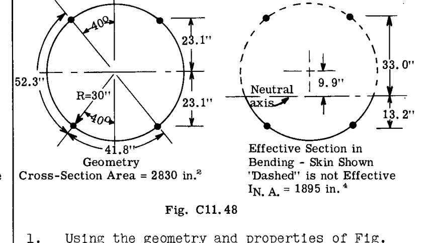

Fig. C11.48

1. Fig. C11.48 の幾何形状と特性、および曲げの工学理論を使用して、一次内部応力を次のように求める：

$$f_{\text{upper long.}} = \frac{MZ}{I} = \frac{-2,135,000(33)}{1895} =
-37,200 \text{ psi (comp.)}$$

$$f_{\text{stop skin}} = \frac{T}{2At} = \frac{600,000}{2(2830)(.025)} =
4240 \text{ psi}$$

$$f_{\text{sside skins}} = \pm \frac{T}{2At} + \frac{VQ}{2It} = 4240 +
\frac{18,000(2 \times .60 \times 33)}{2 (1895)(.025)} = 11,780 \text{
psi}$$

$$f_{\text{lower long.}} = \frac{MZ}{I} = \frac{-2,135,000(-13.2)}{1895} =
+14,800 \text{ (tens.)}$$